# Predicting High School Student Academic Performance based on Alcohol Consumption and Other Characteristics

## Spring 2026 Data Science Project — CMSC 320

**Authors:** David Ahn, Konstantinos Paparrizos, Jeffrey Xu, Rishi Khosla

### Contributions:

Project idea - David Ahn, Konstantinos Paparrizos, Jeffrey Xu, Rishi Khosla

- During our meetings, all the members of our team contributed to brainstorming our project idea and research questions.  
  Dataset Curation and Preprocessing - David Ahn, Konstantinos Paparrizos, Jeffrey Xu, Rishi Khosla
- During our meetings, all the members of our team contributed to finding a dataset aligned with our project idea. Rishi performed most of the data preprocessing, including feature engineering, and Konstantinos made some small adjustments.  
  Data Exploration and Summary Statistics - David Ahn, Konstantinos Paparrizos, Jeffrey Xu, Rishi Khosla
- All the members of our team contributed to data exploration and summary statistics. Rishi explored descriptive statistics and shared his findings, while David, Konstantinos, and Jeffrey all performed hypothesis testing, exploratory data analysis, and visualization  
  ML Algorithm Design/Development - David Ahn, Konstantinos Paparrizos, Jeffrey Xu, Rishi Khosla
- All the members of our team contributed to designing and developing the machine learning algorithms we used in our analysis. Jeffrey worked on linear regression, Rishi worked on random forest, Konstantinos worked on the neural network, and David worked on the decision tree.  
  ML Algorithm Training and Test Data Analysis - David Ahn, Konstantinos Paparrizos, Jeffrey Xu, Rishi Khosla
- All the members of our team contributed to training and analysing the results of the machine learning algorithms we used. Rishi performed Principal Component Analysis and trained and analysed our random forest model, Jeffrey trained and analysed our linear regression model, Konstantinos trained and analysed our neural network, and David trained and analysed our decision tree.  
  Visualization, Result Analysis, Conclusion - David Ahn, Konstantinos Paparrizos, Jeffrey Xu, Rishi Khosla
- All the members of our team contributed to visualizing and analysing the results of our research, or our insights and conclusions section. Each group member performed visualization and analysis for their machine learning algorithms that they implemented, along with the parts of the data exploration section that they worked on, and David and Konstantinos wrote the conclusion section of the tutorial.  
  Final Tutorial Report Creation - David Ahn, Konstantinos Paparrizos, Jeffrey Xu, Rishi Khosla
- All group members contributed to the creation of the final tutorial report through the contributions described above.

# Introduction

Underage alcohol consumption is an important and extensive issue in the United States. According to the CDC, when surveyed, almost 20% of high school students reported drinking in the past month (CDC). Underage alcohol consumption has many negative impacts on the mental and physical health of students, including slower brain development, increased rate of injuries, and increased spread of sexually transmitted infections (CDC). Additionally, underage drinking can lead to more absences from school and worse grades (CDC). To better understand this issue, we want to explore and quantify the effects of alcohol consumption on the academic performance of students. In particular, we want to see if the academic performance of students can be predicted given information about their alcohol consumption and other characteristics. We also want to explore if it is alcohol consumption or other correlated factors that are driving the variation in the academic performance of students. By exploring these questions we will gain a better understanding of how alcohol impacts students academically, enabling future stake holders to make decisions that better support students and address the effects of underage drinking.

# Data Curation

## Citing and Explaining Data

We are choosing to use the Student Alcohol Consumption dataset on Kaggle. This dataset was collected by Paulo Cortez and Alice Silva for their paper "Using Data Mining to Predict Secondary School Student Performance" (Cortez and Silva). The dataset is maintained online by the University of California Irvine Machine Learning Repository (Cortez and Silva). We chose this dataset because it has enough detail to support meaningful analysis and modeling. The dataset contains a variety of features describing hundreds of students, including their family size, sex, grades, and, most importantly, their weekend alcohol consumption (Cortez and Silva). The numerous data, including multiple numerical and categorical features within the dataset, will enable us to conduct machine learning analysis, hypothesis testing, and data visualization, and enable us to explore our research questions in depth, making this dataset appropriate for our project.

## Importing Libraries

We begin by importing all of the libraries needed for our tutorial. This includes kagglehub for loading the dataset, pandas for basic data manipulation and analysis, numpy for performing the necessary mathematical operations, Matplotlib and seaborn for data visualization, SciPy and statsmodels for hypothesis testing and exploratory data analysis, and scikit-learn and PyTorch for machine learning analysis.

```python
!pip install torchmetrics
import kagglehub
import os
import numpy as np
import pandas as pd
import matplotlib.pyplot as plt
import matplotlib.patches as mpatches
import torchmetrics
import seaborn as sns
from scipy import stats
from scipy.stats import gaussian_kde
from statsmodels.stats.weightstats import ztest

from sklearn import tree
from sklearn.model_selection import train_test_split, StratifiedKFold, cross_val_score
from sklearn.preprocessing import StandardScaler, label_binarize, PowerTransformer
from sklearn.decomposition import PCA
from sklearn.linear_model import LinearRegression
from sklearn.ensemble import RandomForestRegressor
from sklearn.model_selection import KFold
from sklearn.svm import LinearSVC
from sklearn.linear_model import LogisticRegression
from sklearn.tree import DecisionTreeRegressor
from sklearn.metrics import (
    accuracy_score, classification_report,
    hinge_loss, confusion_matrix, ConfusionMatrixDisplay
)
from sklearn.metrics import mean_squared_error, r2_score

import torch
import torch.nn as nn
import torch.optim as optim
from torch.utils.data import DataLoader, TensorDataset
from torchmetrics.regression import R2Score
import os
torch.set_num_threads(os.cpu_count() or 1)
# to ensure reproducability
np.random.seed(42)
torch.manual_seed(42)
torch.backends.cudnn.deterministic = True
torch.backends.cudnn.benchmark = False
```

## Load the Raw Dataset

We import the dataset as a CSV using kagglehub and then use read_csv to create a DataFrame containing the data. We also examine the shape and head of the DataFrame to ensure the data was loaded correctly.

```python
path = kagglehub.dataset_download("uciml/student-alcohol-consumption")

csv_file_name = "student-mat.csv"
full_csv_path = os.path.join(path, csv_file_name)

df_raw = pd.read_csv(full_csv_path)
print(f"Raw dataset shape: {df_raw.shape}")
df_raw.head(10)
```

```
Using Colab cache for faster access to the 'student-alcohol-consumption' dataset.
Raw dataset shape: (395, 33)
```

|  | school | sex | age | address | famsize | Pstatus | Medu | Fedu | Mjob | Fjob | ... | famrel | freetime | goout | Dalc | Walc | health | absences | G1 | G2 | G3 |
| --- | --- | --- | --- | --- | --- | --- | --- | --- | --- | --- | --- | --- | --- | --- | --- | --- | --- | --- | --- | --- | --- |
| 0 | GP | F | 18 | U | GT3 | A | 4 | 4 | at_home | teacher | ... | 4 | 3 | 4 | 1 | 1 | 3 | 6 | 5 | 6 | 6 |
| 1 | GP | F | 17 | U | GT3 | T | 1 | 1 | at_home | other | ... | 5 | 3 | 3 | 1 | 1 | 3 | 4 | 5 | 5 | 6 |
| 2 | GP | F | 15 | U | LE3 | T | 1 | 1 | at_home | other | ... | 4 | 3 | 2 | 2 | 3 | 3 | 10 | 7 | 8 | 10 |
| 3 | GP | F | 15 | U | GT3 | T | 4 | 2 | health | services | ... | 3 | 2 | 2 | 1 | 1 | 5 | 2 | 15 | 14 | 15 |
| 4 | GP | F | 16 | U | GT3 | T | 3 | 3 | other | other | ... | 4 | 3 | 2 | 1 | 2 | 5 | 4 | 6 | 10 | 10 |
| 5 | GP | M | 16 | U | LE3 | T | 4 | 3 | services | other | ... | 5 | 4 | 2 | 1 | 2 | 5 | 10 | 15 | 15 | 15 |
| 6 | GP | M | 16 | U | LE3 | T | 2 | 2 | other | other | ... | 4 | 4 | 4 | 1 | 1 | 3 | 0 | 12 | 12 | 11 |
| 7 | GP | F | 17 | U | GT3 | A | 4 | 4 | other | teacher | ... | 4 | 1 | 4 | 1 | 1 | 1 | 6 | 6 | 5 | 6 |
| 8 | GP | M | 15 | U | LE3 | A | 3 | 2 | services | other | ... | 4 | 2 | 2 | 1 | 1 | 1 | 0 | 16 | 18 | 19 |
| 9 | GP | M | 15 | U | GT3 | T | 3 | 4 | other | other | ... | 5 | 5 | 1 | 1 | 1 | 5 | 0 | 14 | 15 | 15 |

10 rows × 33 columns

We call the info and describe functions to gain a better understanding of the structure of the dataset, including the columns in the dataset and the datatypes they store.

```python
print("Dataset Info")
df_raw.info()

print("\nNumeric Summary")
df_raw.describe()
```

```
Dataset Info
<class 'pandas.core.frame.DataFrame'>
RangeIndex: 395 entries, 0 to 394
Data columns (total 33 columns):
 #   Column      Non-Null Count  Dtype
---  ------      --------------  -----
 0   school      395 non-null    object
 1   sex         395 non-null    object
 2   age         395 non-null    int64
 3   address     395 non-null    object
 4   famsize     395 non-null    object
 5   Pstatus     395 non-null    object
 6   Medu        395 non-null    int64
 7   Fedu        395 non-null    int64
 8   Mjob        395 non-null    object
```

[output cut: 28 more lines]

|  | age | Medu | Fedu | traveltime | studytime | failures | famrel | freetime | goout | Dalc | Walc | health | absences | G1 | G2 | G3 |
| --- | --- | --- | --- | --- | --- | --- | --- | --- | --- | --- | --- | --- | --- | --- | --- | --- |
| count | 395.000000 | 395.000000 | 395.000000 | 395.000000 | 395.000000 | 395.000000 | 395.000000 | 395.000000 | 395.000000 | 395.000000 | 395.000000 | 395.000000 | 395.000000 | 395.000000 | 395.000000 | 395.000000 |
| mean | 16.696203 | 2.749367 | 2.521519 | 1.448101 | 2.035443 | 0.334177 | 3.944304 | 3.235443 | 3.108861 | 1.481013 | 2.291139 | 3.554430 | 5.708861 | 10.908861 | 10.713924 | 10.415190 |
| std | 1.276043 | 1.094735 | 1.088201 | 0.697505 | 0.839240 | 0.743651 | 0.896659 | 0.998862 | 1.113278 | 0.890741 | 1.287897 | 1.390303 | 8.003096 | 3.319195 | 3.761505 | 4.581443 |
| min | 15.000000 | 0.000000 | 0.000000 | 1.000000 | 1.000000 | 0.000000 | 1.000000 | 1.000000 | 1.000000 | 1.000000 | 1.000000 | 1.000000 | 0.000000 | 3.000000 | 0.000000 | 0.000000 |
| 25% | 16.000000 | 2.000000 | 2.000000 | 1.000000 | 1.000000 | 0.000000 | 4.000000 | 3.000000 | 2.000000 | 1.000000 | 1.000000 | 3.000000 | 0.000000 | 8.000000 | 9.000000 | 8.000000 |
| 50% | 17.000000 | 3.000000 | 2.000000 | 1.000000 | 2.000000 | 0.000000 | 4.000000 | 3.000000 | 3.000000 | 1.000000 | 2.000000 | 4.000000 | 4.000000 | 11.000000 | 11.000000 | 11.000000 |
| 75% | 18.000000 | 4.000000 | 3.000000 | 2.000000 | 2.000000 | 0.000000 | 5.000000 | 4.000000 | 4.000000 | 2.000000 | 3.000000 | 5.000000 | 8.000000 | 13.000000 | 13.000000 | 14.000000 |
| max | 22.000000 | 4.000000 | 4.000000 | 4.000000 | 4.000000 | 3.000000 | 5.000000 | 5.000000 | 5.000000 | 5.000000 | 5.000000 | 5.000000 | 75.000000 | 19.000000 | 19.000000 | 20.000000 |

As we can see from above, the dataset contains information on 395 students, and stores 33 features describing these students. We can also see that the dataset contains a mix of both continuous and categorical features that we can use for our analysis. Additionally, it seems that most of the numeric data is also categorical, and corresponds to different ratings for different attributes. The only continuous data contained in the dataset appears to be grade data (G1, G2, G3) and the number of absences reported.

## Preprocessing Data

### Feature Engineering

```python
df = df_raw.copy()

# Using binary label encoding for binary variables, which should be sufficient
binary_mappings = {
    'famsize': {'LE3': 0, 'GT3': 1},
    'schoolsup': {'no': 0, 'yes': 1},
    'famsup': {'no': 0, 'yes': 1},
    'paid': {'no': 0, 'yes': 1},
    'activities': {'no': 0, 'yes': 1},
    'nursery': {'no': 0, 'yes': 1},
    'higher': {'no': 0, 'yes': 1},
    'internet': {'no': 0, 'yes': 1},
    'romantic': {'no': 0, 'yes': 1}
}

df.replace(binary_mappings, inplace=True)

# One-hot encode remaining categorical columns
df = pd.get_dummies(
    df,
    columns=['school', 'sex', 'address', 'Pstatus', 'Mjob', 'Fjob', 'reason', 'guardian'],
    drop_first=True,
    dtype=int,
)

print(df.shape)
df.head()
```

```
(395, 42)
```

|  | age | famsize | Medu | Fedu | traveltime | studytime | failures | schoolsup | famsup | paid | ... | Mjob_teacher | Fjob_health | Fjob_other | Fjob_services | Fjob_teacher | reason_home | reason_other | reason_reputation | guardian_mother | guardian_other |
| --- | --- | --- | --- | --- | --- | --- | --- | --- | --- | --- | --- | --- | --- | --- | --- | --- | --- | --- | --- | --- | --- |
| 0 | 18 | 1 | 4 | 4 | 2 | 2 | 0 | 1 | 0 | 0 | ... | 0 | 0 | 0 | 0 | 1 | 0 | 0 | 0 | 1 | 0 |
| 1 | 17 | 1 | 1 | 1 | 1 | 2 | 0 | 0 | 1 | 0 | ... | 0 | 0 | 1 | 0 | 0 | 0 | 0 | 0 | 0 | 0 |
| 2 | 15 | 0 | 1 | 1 | 1 | 2 | 3 | 1 | 0 | 1 | ... | 0 | 0 | 1 | 0 | 0 | 0 | 1 | 0 | 1 | 0 |
| 3 | 15 | 1 | 4 | 2 | 1 | 3 | 0 | 0 | 1 | 1 | ... | 0 | 0 | 0 | 1 | 0 | 1 | 0 | 0 | 1 | 0 |
| 4 | 16 | 1 | 3 | 3 | 1 | 2 | 0 | 0 | 1 | 1 | ... | 0 | 0 | 1 | 0 | 0 | 1 | 0 | 0 | 0 | 0 |

5 rows × 42 columns

After performing our feature encoding, we can see the dataset now has 42 columns corresponding to various features.

### Checking for Missing Values

The raw dataset contains no missing values. We show the standard workflow by putting in NaN values into the age column and then removing them. If new data were to be added with missing values, this would find and correct them.

```python
print("Missing values (raw):", df.isnull().sum().max())

df.loc[0:4, 'age'] = np.nan
print("Missing values after injection (age):", df['age'].isnull().sum())

df.dropna(inplace=True)
print("Missing values after dropna:", df['age'].isnull().sum())
```

```
Missing values (raw): 0
Missing values after injection (age): 5
Missing values after dropna: 0
```

### Checking for Duplicated Values

We also check for duplicated entries, of which there are none.

```python
print("Duplicated values :", df.duplicated().sum())
```

[output not shown]

### Feature Transformation

To ensure our continuous data is ready for machine learning analysis, we plot and print out descriptive statistics corresponding to continuous features.

```
count    390.000000
mean      10.951282
std        3.291367
min        3.000000
25%        8.000000
50%       11.000000
75%       13.000000
max       19.000000
Name: G1, dtype: float64
```

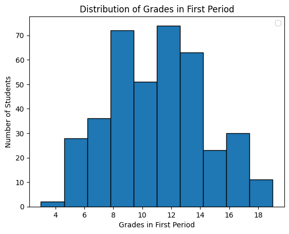

```python
print(df['G1'].describe())
plt.hist(df['G1'], edgecolor='black')
plt.xlabel("Grades in First Period")
plt.ylabel("Number of Students")
plt.title("Distribution of Grades in First Period")
plt.legend()
plt.show()
```

```
count    390.000000
mean      10.741026
std        3.760450
min        0.000000
25%        9.000000
50%       11.000000
75%       13.000000
max       19.000000
Name: G2, dtype: float64
```

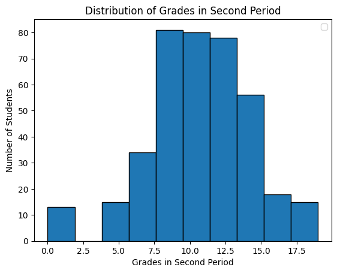

```python
print(df['G2'].describe())
plt.hist(df['G2'], edgecolor='black')
plt.xlabel("Grades in Second Period")
plt.ylabel("Number of Students")
plt.title("Distribution of Grades in Second Period")
plt.legend()
plt.show()
```

```
count    390.000000
mean      10.428205
std        4.593918
min        0.000000
25%        8.000000
50%       11.000000
75%       14.000000
max       20.000000
Name: G3, dtype: float64
```

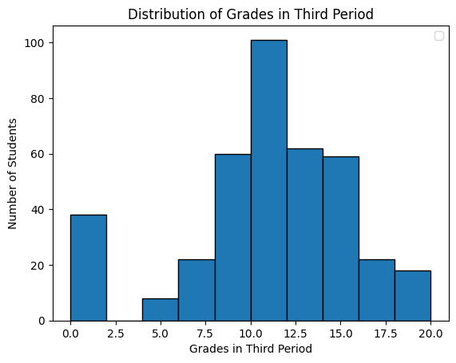

```python
print(df['G3'].describe())
plt.hist(df['G3'], edgecolor='black')
plt.xlabel("Grades in Third Period")
plt.ylabel("Number of Students")
plt.title("Distribution of Grades in Third Period")
plt.legend()
plt.show()
```

We can see that the grade data is relatively normally distributed. As such, there is no need to perform any normalization on these features.

```
count    390.000000
mean       5.715385
std        8.048281
min        0.000000
25%        0.000000
50%        4.000000
75%        8.000000
max       75.000000
Name: absences, dtype: float64
```

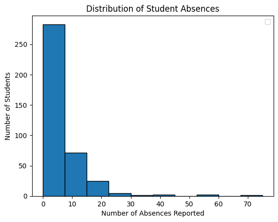

```python
print(df['absences'].describe())
plt.hist(df['absences'], edgecolor='black')
plt.xlabel("Number of Absences Reported")
plt.ylabel("Number of Students")
plt.title("Distribution of Student Absences")
plt.legend()
plt.show()
```

```python
transformer = PowerTransformer(method = "box-cox")

df["absences"] = df["absences"] + 1 # method expects only positive numbers so we need to shift by one
df["absences"] = transformer.fit_transform(df[["absences"]])
```

```
count    3.900000e+02
mean    -1.184238e-16
std      1.001285e+00
min     -1.304708e+00
25%     -1.304708e+00
50%      2.512604e-01
75%      7.935716e-01
max      2.652280e+00
Name: absences, dtype: float64
```

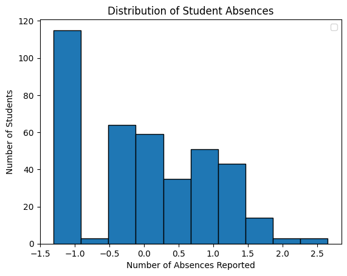

```python
print(df['absences'].describe())
plt.hist(df['absences'], edgecolor='black')
plt.xlabel("Number of Absences Reported")
plt.ylabel("Number of Students")
plt.title("Distribution of Student Absences")
plt.legend()
plt.show()
```

### Feature Creation

We perform feature creation using the daily alcohol consumption (Dalc), weekly alcohol consumption (Walc), and grade features (G1, G2, G3) to simplify the interpretation and analysis of student alcohol consumption and academic performance.

**Calc**: Average of workday (Dalc) and weekend (Walc) alcohol consumption, giving a single weekly alcohol composite score on the 1–5 scale.

**GPA**: Average of the three period grades (G1, G2, G3), each scored out of 20. Dividing by 5 scales this to a 0–4 range to give a GPA-like metric.

```python
df['Calc'] = (df['Dalc'] + df['Walc']) / 2
df['GPA']  = (df['G1']  + df['G2']  + df['G3']) / 15   # max 60 -> scale to 0-4

print(f"Final dataset shape: {df.shape}")
df.info()
df.describe
```

```
Final dataset shape: (390, 44)
<class 'pandas.core.frame.DataFrame'>
Index: 390 entries, 5 to 394
Data columns (total 44 columns):
 #   Column             Non-Null Count  Dtype
---  ------             --------------  -----
 0   age                390 non-null    float64
 1   famsize            390 non-null    int64
 2   Medu               390 non-null    int64
 3   Fedu               390 non-null    int64
 4   traveltime         390 non-null    int64
 5   studytime          390 non-null    int64
 6   failures           390 non-null    int64
 7   schoolsup          390 non-null    int64
 8   famsup             390 non-null    int64
```

[output cut: 37 more lines]

[output not shown]

[output not shown]

[output cut: 178 more lines]

[output not shown]

### Examining Data after Preprocessing

```python
print(f"Dataset Shape (Rows, Columns): {df.shape}\n")

print("Final Data Types and Completeness")
df.info()

df[['age', 'Walc']].head()
```

```
Dataset Shape (Rows, Columns): (390, 44)

Final Data Types and Completeness
<class 'pandas.core.frame.DataFrame'>
Index: 390 entries, 5 to 394
Data columns (total 44 columns):
 #   Column             Non-Null Count  Dtype
---  ------             --------------  -----
 0   age                390 non-null    float64
 1   famsize            390 non-null    int64
 2   Medu               390 non-null    int64
 3   Fedu               390 non-null    int64
 4   traveltime         390 non-null    int64
 5   studytime          390 non-null    int64
 6   failures           390 non-null    int64
```

[output cut: 39 more lines]

|  | age | Walc |
| --- | --- | --- |
| 5 | 16.0 | 2 |
| 6 | 16.0 | 1 |
| 7 | 17.0 | 1 |
| 8 | 15.0 | 1 |
| 9 | 15.0 | 1 |

After cleaning and preprocessing the data, our dataset now contains 44 features and 390 instances. We are now ready to perform further analysis!

# EDA (Exploratory Data Analysis)

## Descriptive Statistics

Considering that our dataset and analysis is centered on student alcohol consumption and academic performance, it is critical to understand the statistics related to how much students consume alcohol throughout the week, along with their GPAs and academic information. We will now use descriptive statistics to further understand the data pertaining to workday and weekend alcohol consumption and academic performance in the dataset.

### Weekday Alcohol Consumption

To better understand the information on student workday alcohol consumption, we will first use a histogram to visualize the distribution of students in different categorical groups corresponding to self-ratings of how much they consume alcohol on workdays.

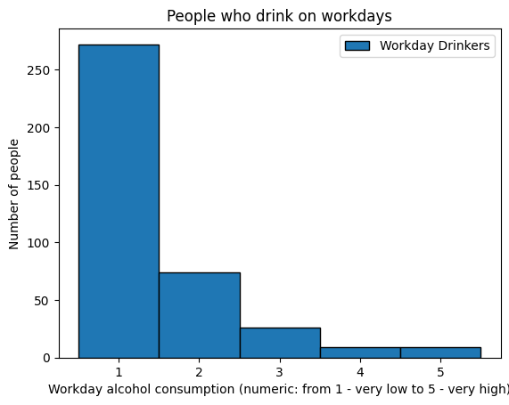

```python
df['Dalc'].describe()
plt.hist(df['Dalc'], bins=5, range=(0.5, 5.5), edgecolor='black', label='Workday Drinkers')
plt.xlabel("Workday alcohol consumption (numeric: from 1 - very low to 5 - very high)")
plt.ylabel("Number of people")
plt.title("People who drink on workdays")
plt.legend()
plt.show()
```

It appears that most students consume little to no alcohol, and only a few students have high self-ratings of alcohol consumption. Next, we will use the describe function to see various descriptive statistics on workday alcohol consumption.

```python
df['Dalc'].describe()
```

|  | Dalc |
| --- | --- |
| count | 390.000000 |
| mean | 1.484615 |
| std | 0.894726 |
| min | 1.000000 |
| 25% | 1.000000 |
| 50% | 1.000000 |
| 75% | 2.000000 |
| max | 5.000000 |

**dtype:** float64

As the histogram indicates, there is a relatively low mean workday alcohol consumption of 1.48. The standard deviations is 0.89, indicating a moderate amount of variation in workday alcohol consumption. Overall, it seems that workday alcohol consumption is not a very popular trend for students in the dataset.

### Weekend Alcohol Consumption

Likewise, to better understand the information on weekend student alcohol consumption, we will first use a histogram to visualize the distribution of students in different categorical groups corresponding to self-ratings of how much they consume alcohol on the weekends.

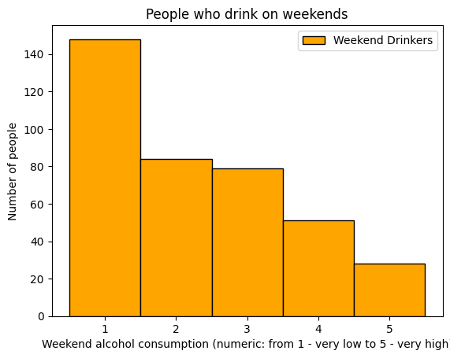

```python
df['Walc'].describe()
plt.hist(df['Walc'], bins=5, range=(0.5, 5.5), edgecolor='black', color='orange', label='Weekend Drinkers')
plt.xlabel("Weekend alcohol consumption (numeric: from 1 - very low to 5 - very high)")
plt.ylabel("Number of people")
plt.title("People who drink on weekends")
plt.legend()
plt.show()
```

```python
df['Walc'].describe()
```

|  | Walc |
| --- | --- |
| count | 390.000000 |
| mean | 2.300000 |
| std | 1.290563 |
| min | 1.000000 |
| 25% | 1.000000 |
| 50% | 2.000000 |
| 75% | 3.000000 |
| max | 5.000000 |

**dtype:** float64

As the histogram suggests, there is a higher mean weekend alcohol consumption rating for students, compared to workday alcohol consumption. There is also a higher standard deviation of 1.29, suggesting a higher variation in alcohol consumption habits on the weekend. It appears that a majority of students do appear to engage in drinking on the weekend. The higher variation in weekend alcohol consumption will make it a useful for exmaining how different alcohol consumption ratings may influence academic performance.

### Grades

We will now plot the grades and GPAs of students to gain a better understanding of student academic performance.

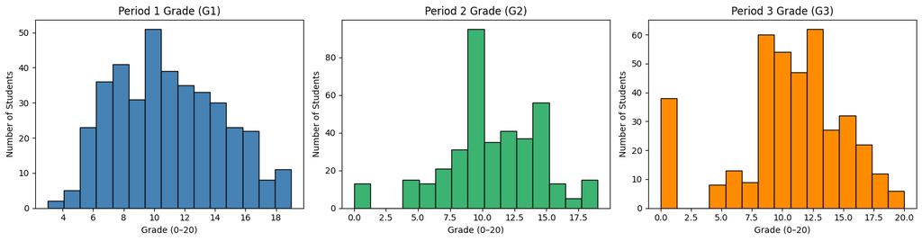

```python
fig, axes = plt.subplots(1, 3, figsize=(15, 4))
colors = ['steelblue', 'mediumseagreen', 'darkorange']
for i, (col, ax, color) in enumerate(zip(['G1', 'G2', 'G3'], axes, colors)):
    ax.hist(df[col], bins=15, edgecolor='black', color=color)
    ax.set_xlabel("Grade (0–20)")
    ax.set_ylabel("Number of Students")
    ax.set_title(f"Period {i+1} Grade ({col})")
plt.tight_layout()
plt.show()
```

Overall, it appears that there is relatively high variation in the grades of students for all 3 periods. The data for all three periods also appears to be relatively normally distributed.

```python
print(df['G1'].describe())
print(df['G2'].describe())
print(df['G3'].describe())
```

```
count    390.000000
mean      10.951282
std        3.291367
min        3.000000
25%        8.000000
50%       11.000000
75%       13.000000
max       19.000000
Name: G1, dtype: float64
count    390.000000
mean      10.741026
std        3.760450
min        0.000000
25%        9.000000
50%       11.000000
75%       13.000000
max       19.000000
Name: G2, dtype: float64
count    390.000000
mean      10.428205
std        4.593918
min        0.000000
25%        8.000000
50%       11.000000
75%       14.000000
max       20.000000
Name: G3, dtype: float64
```

The summary statistics confirm that there is a relatively high variation in grades for all 3 periods, with all three features having a standard deviation greater than 3. Additionally, the mean for all three features appears to align closely with the median, suggesting that there is little skew to the data. The high variation in grade data is promising for feature machine learning analysis so we can understand the factors that may cause this variation.

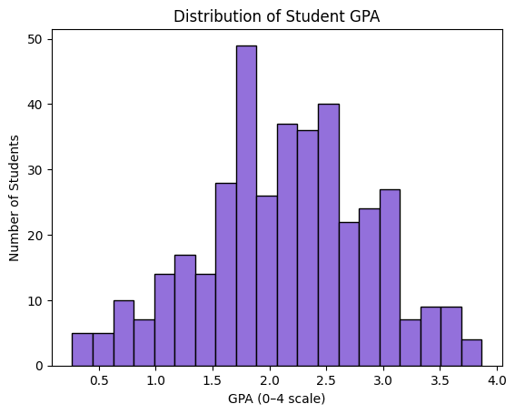

```python
plt.hist(df['GPA'], bins=20, edgecolor='black', color='mediumpurple')
plt.xlabel("GPA (0–4 scale)")
plt.ylabel("Number of Students")
plt.title("Distribution of Student GPA")
plt.show()
```

```python
print(df['GPA'].describe())
```

```
count    390.000000
mean       2.141368
std        0.738583
min        0.266667
25%        1.666667
50%        2.133333
75%        2.666667
max        3.866667
Name: GPA, dtype: float64
```

The GPA data displays similar statistics, including its variation and distribution shape, as the grade data, which aligns with what we would expect. The GPA feature will be useful because it combines information from the three grade features into one that we can analyse more easily.

### GPA vs Lifestyle Factors

Since we are interested in predicting academic performance and understandng how it relates to other student characteristics, we will also analyze the relationship between GPA and student lifestyle factors.

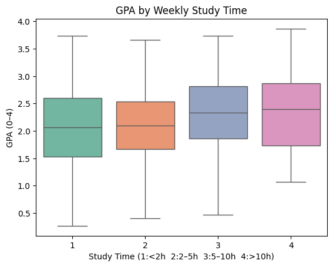

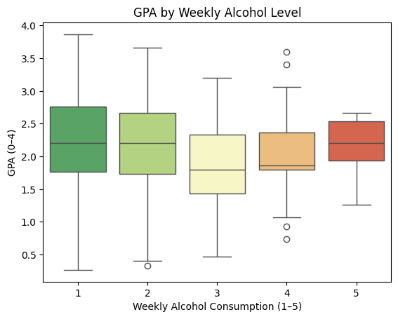

```python
df['Calc_bin'] = df['Calc'].round().astype(int)

sns.boxplot(data=df, x='studytime', y='GPA', palette='Set2')
plt.xlabel("Study Time (1:<2h  2:2–5h  3:5–10h  4:>10h)")
plt.ylabel("GPA (0–4)")
plt.title("GPA by Weekly Study Time")
plt.show()

sns.boxplot(data=df, x='Calc_bin', y='GPA', palette='RdYlGn_r')
plt.xlabel("Weekly Alcohol Consumption (1–5)")
plt.ylabel("GPA (0–4)")
plt.title("GPA by Weekly Alcohol Level")
plt.show()
```

When looking at the first box plot, it appears that a relationship between student study time and GPA does exist. Students with higher self-rated study times appear to have higher median GPAs, although there is still a large amount of variation, indicating that study habits have an impact on academic performance. On the other hand, there is not a clear relationship between alcohol consumption and GPA. It appears that students with alcohol consumption ratings near 1, 2, and 5 have higher median GPAs than those with ratings of 3 and 4, though these results are not at all conclusive.

Lastly, we will create a Pearson Correlation Matrix to visualize how all of the features relate to each other.

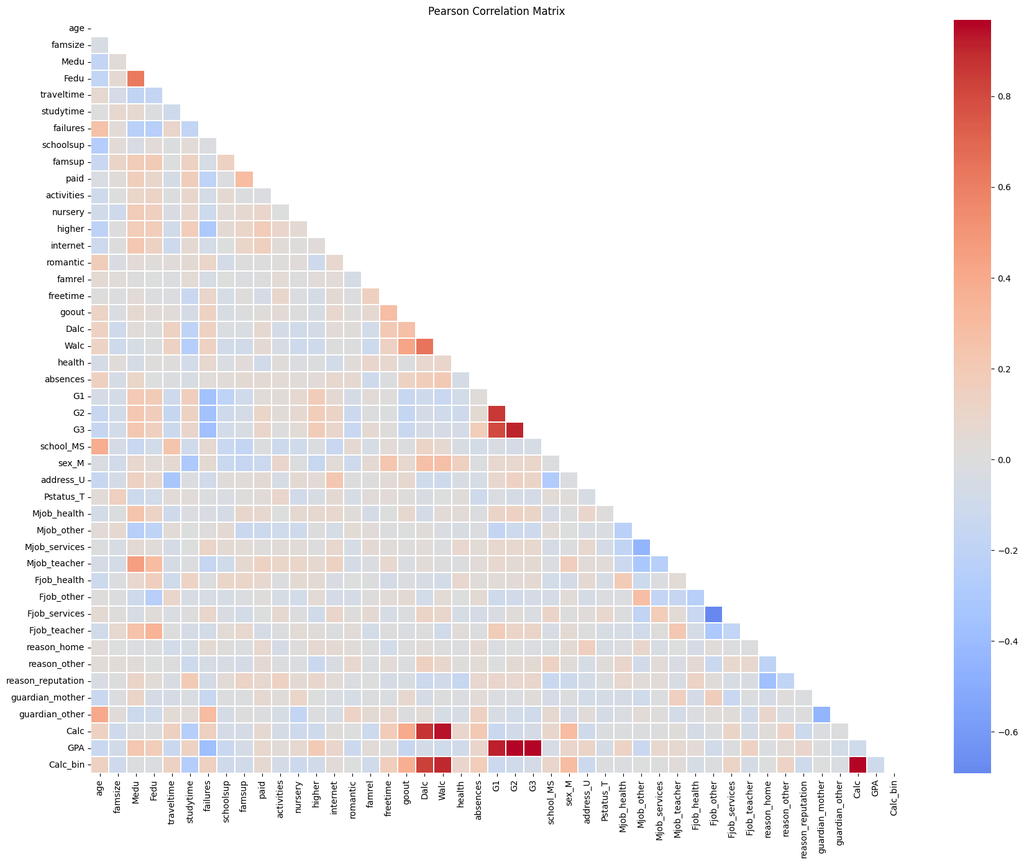

```
Top 10 features correlated with GPA:
G2              0.968
G3              0.961
G1              0.920
failures       -0.382
Medu            0.221
higher          0.193
Fedu            0.178
goout          -0.154
Fjob_teacher    0.137
studytime       0.132
Name: GPA, dtype: float64
```

```python
numeric_cols = df.select_dtypes(include=[np.number]).columns.tolist()
corr = df[numeric_cols].corr()

plt.figure(figsize=(18, 14))
mask = np.triu(np.ones_like(corr, dtype=bool))
sns.heatmap(corr, mask=mask, annot=False, cmap='coolwarm', center=0, linewidths=0.3)
plt.title("Pearson Correlation Matrix")
plt.tight_layout()
plt.show()

gpa_corr = corr['GPA'].drop('GPA').sort_values(key=abs, ascending=False)
print("Top 10 features correlated with GPA:")
print(gpa_corr.head(10).round(3))
```

## Examining Data Structure and Relationships

## Hypothesis Testing

We will now test three hypotheses at α = 0.05 to validate EDA observations and inform feature selection for our machine learning analysis.

## Does Alcohol Consumption Affect GPA?

- **H₀:** No relationship between weekly alcohol consumption and GPA.
- **Hₐ:** Significant relationship exists.

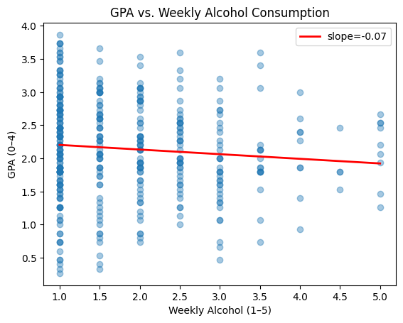

```python
m, b = np.polyfit(df['Calc'], df['GPA'], 1)
x_line = np.linspace(df['Calc'].min(), df['Calc'].max(), 100)
plt.scatter(df['Calc'], df['GPA'], alpha=0.4)
plt.plot(x_line, m * x_line + b, color='red', linewidth=2, label=f'slope={m:.2f}')
plt.xlabel("Weekly Alcohol (1–5)")
plt.ylabel("GPA (0–4)")
plt.title("GPA vs. Weekly Alcohol Consumption")
plt.legend()
plt.show()
```

Because our hypothesis involves two continuous variables we will use Spearman's rank correlation coefficient to test our hypothesis.

```python
res = stats.spearmanr(a=df['Calc'], b=df['GPA'])
print(f"Spearman's rho : {res.statistic:.4f}")
print(f"P-value        : {res.pvalue:.4e}")

if res.pvalue < 0.05:
    print("\nResult: REJECT H0 — significant negative relationship between alcohol and GPA.")
else:
    print("\nResult: FAIL TO REJECT H0")
```

```
Spearman's rho : -0.1133
P-value        : 2.5238e-02

Result: REJECT H0 — significant negative relationship between alcohol and GPA.
```

Our p-value of ~ 0.025 < 0.05 so we reject the null hypothesis. Spearman's rho ~ −0.11 confirms that heavier drinkers earn lower GPAs. As such, it does appear that weekly alcohol consumption has an impact on academic performance, which is promising for our machine learning analysis and research objective.

### Does Gender Affect GPA?

- **H₀:** No difference in mean GPA between male and female students.
- **Hₐ:** Significant difference exists.

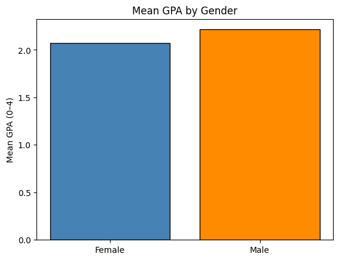

```python
df_plot = df.copy()
df_plot['Gender'] = df_plot['sex_M'].map({0: 'Female', 1: 'Male'})
means = df_plot.groupby('Gender')['GPA'].mean()
plt.bar(means.index, means.values, color=['steelblue', 'darkorange'], edgecolor='black')
plt.ylabel("Mean GPA (0–4)")
plt.title("Mean GPA by Gender")
plt.show()
```

Since we have a relatively large sample size and two groups that we are examining with unknown standard deviations, we will use a t-test for this hypothesis.

```python
females_gpa = df[df['sex_M'] == 0]['GPA']
males_gpa   = df[df['sex_M'] == 1]['GPA']

print(f"Female — n={len(females_gpa)}, mean GPA = {females_gpa.mean():.3f}")
print(f"Male   — n={len(males_gpa)},   mean GPA = {males_gpa.mean():.3f}")

t_stat, p_gender = stats.ttest_ind(females_gpa, males_gpa, alternative='two-sided')
print(f"T-statistic : {t_stat:.4f}")
print(f"P-value     : {p_gender:.4e}")

if p_gender < 0.05:
    print("Result: REJECT H0 — significant GPA difference between genders.")
else:
    print("Result: FAIL TO REJECT H0")
```

```
Female — n=203, mean GPA = 2.074
Male   — n=187,   mean GPA = 2.215
T-statistic : -1.8860
P-value     : 6.0048e-02
Result: FAIL TO REJECT H0
```

### Does Living Location Affect GPA?

- **H₀:** No difference in mean GPA between urban and rural students.
- **Hₐ:** Significant difference exists.

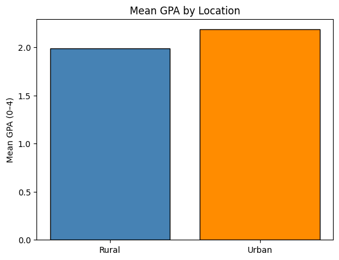

```python
# address one-hot encoded: address_U = 1 means Urban
df_loc = df.copy()
df_loc['Location'] = df_loc['address_U'].map({1: 'Urban', 0: 'Rural'})
means = df_loc.groupby('Location')['GPA'].mean()
plt.bar(means.index, means.values, color=['steelblue', 'darkorange'], edgecolor='black')
plt.ylabel("Mean GPA (0–4)")
plt.title("Mean GPA by Location")
plt.show()
```

Since we have a relatively large sample size and two groups that we are examining with unknown standard deviations, we will also use a t-test for this hypothesis.

```python
# address_U: 1 = Urban, 0 = Rural (from one-hot encoding with drop_first)
urban_gpa = df[df['address_U'] == 1]['GPA']
rural_gpa = df[df['address_U'] == 0]['GPA']

print(f"Urban — n={len(urban_gpa)}, mean GPA = {urban_gpa.mean():.3f}")
print(f"Rural — n={len(rural_gpa)}, mean GPA = {rural_gpa.mean():.3f}")

t_stat, p_loc = stats.ttest_ind(urban_gpa, rural_gpa, equal_var=False)
print(f"T-statistic : {t_stat:.4f}")
print(f"P-value     : {p_loc:.4f}")

if p_loc < 0.05:
    print("Result: REJECT H0 — significant GPA difference by location.")
else:
    print("Result: FAIL TO REJECT H0")
```

```
Urban — n=302, mean GPA = 2.186
Rural — n=88, mean GPA = 1.988
T-statistic : 2.2100
P-value     : 0.0287
Result: REJECT H0 — significant GPA difference by location.
```

Our p-value of ~ 0.028 < 0.05 so we reject the null hypothesis. As such, it does appear that home location has a statistically significant impact on academic performance, so we may want to consider it as a more important feature for our analysis.

# Analysis

## Model Selection Reasoning

Based on our EDA and hypothesis testing, we train four models:

1. Linear Regression: simple baseline regressor with interpretable coefficients.
2. Random Forest: captures nonlinear interactions and provides feature importances.
3. Decision Tree: interpretable single-tree regressor for comparison.
4. Neural Network (MLP): tests whether extra model capacity improves performance.

All four are regression models predicting continuous GPA (0–4 scale).

## Data Transformation

In order to predict GPA from various different statistics about a person, we must drop multiple columns that are related to grades in order to avoid a data leak. We also drop Dalc, Walc, and Calc_bin because the Calc feature accounts for these features already.

```python
FEATURE_DROPS = ['G1', 'G2', 'G3', 'GPA', 'Dalc', 'Walc', 'Calc_bin']
FEATURE_DROPS = [c for c in FEATURE_DROPS if c in df.columns]

X = df.drop(columns=FEATURE_DROPS)
y_reg = df['GPA']

X_train, X_test, y_train_reg, y_test_reg = train_test_split(X, y_reg, test_size=0.2, random_state=42)
```

The resulting training set will contain 312 samples and the test set will have 78 samples, all of which do not have grade indicators.

## Principal Component Analysis

We need to standardize all the features to 0 mean and unit variance then apply the PCA retaining enough components so that we can explain at least 90% of the total variance. This will reduce dimensionality, but it will preserve the structure of the data.

```python
scaler = StandardScaler()
X_train_scaled = scaler.fit_transform(X_train)
X_test_scaled = scaler.transform(X_test)

pca = PCA(n_components=0.90, random_state=42)
X_train_pca = pca.fit_transform(X_train_scaled)
X_test_pca = pca.transform(X_test_scaled)

n_components = X_train_pca.shape[1]
total_var = pca.explained_variance_ratio_.sum()

print(X_train_pca.shape)
print(pca.explained_variance_ratio_)
print(total_var)
```

```
(312, 28)
[0.08918081 0.06492536 0.05806997 0.05054897 0.04519929 0.04276135
 0.03990242 0.03848261 0.03707119 0.03423785 0.03347408 0.03263497
 0.02895694 0.02829946 0.02786684 0.02635906 0.02494425 0.02391991
 0.02331718 0.02151788 0.02075423 0.02004173 0.0191885  0.01792981
 0.01739083 0.01653186 0.01585042 0.0142173 ]
0.91357507973003
```

28 principle components were needed to capture about 91.4% of the total variance, with no single component dominating. So, the explained variance is spread fairly across the components, and that means that no one feature drives the data.

## Regression Models

Both regression models use the same fit/predict functions. We define a shared `fit_model` and `predict_data` function, then call them for each model.

```python
def fit_model(model, X_train, y_train):
    model.fit(X_train, y_train)
    return model

def predict_data(model, X_train, X_test):
    y_train_pred = model.predict(X_train)
    y_test_pred  = model.predict(X_test)
    return y_train_pred, y_test_pred
```

## Linear Regression

We fit a standard linear regression on the scaled features. This will be the baseline that we can use as a performance floor of sorts to compare the other models to.

```python
linear_model = fit_model(LinearRegression(), X_train_scaled, y_train_reg)
y_linear_train_pred, y_linear_test_pred = predict_data(linear_model, X_train_scaled, X_test_scaled)

r2_lr_train = r2_score(y_train_reg, y_linear_train_pred)
r2_lr_test = r2_score(y_test_reg,  y_linear_test_pred)
mse_lr_train = mean_squared_error(y_train_reg, y_linear_train_pred)
mse_lr_test  = mean_squared_error(y_test_reg,  y_linear_test_pred)

print(f"Train R2 of Linear Regression: {r2_lr_train:.3f}")
print(f"Test R2  of Linear Regression: {r2_lr_test:.3f}")
print(f"Train RMSE: {np.sqrt(mse_lr_train):.3f}")
print(f"Test RMSE:  {np.sqrt(mse_lr_test):.3f}")
```

```
Train R2 of Linear Regression: 0.313
Test R2  of Linear Regression: 0.291
Train RMSE: 0.577
Test RMSE:  0.742
```

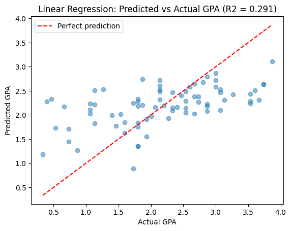

```python
plt.scatter(y_test_reg, y_linear_test_pred, alpha=0.5)
plt.plot([y_test_reg.min(), y_test_reg.max()],
         [y_test_reg.min(), y_test_reg.max()], 'r--', label='Perfect prediction')
plt.xlabel("Actual GPA")
plt.ylabel("Predicted GPA")
plt.title(f"Linear Regression: Predicted vs Actual GPA (R2 = {r2_lr_test:.3f})")
plt.legend()
plt.show()
```

The model achieves a test R2 of 0.291 and RMSE of 0.742, means the model explains about 29% of the GPA variance. The small gap between train and test performance suggests the model is not overfitting, but its limited capacity means it misses nonlinear patterns. This is reflected in the wide variation of points displayed in the predicted vs actual plot above. As such it appears that linear regression is not an ideal model for predicting GPA given the features in our dataset.

## Random Forest

Because linear regression appears to be failing to capture some of the nonlinear patters in the data, we train a 200 tree random forest on the scaled features to capture nonlinear interactions between the variables. We can also use its built in rankings to see which factors most influence GPA.

```python
rf_model = fit_model(
    RandomForestRegressor(n_estimators=200, min_samples_leaf=3, random_state=42, n_jobs=-1),
    X_train_scaled, y_train_reg
)
y_rf_train_pred, y_rf_test_pred = predict_data(rf_model, X_train_scaled, X_test_scaled)

r2_rf_train  = r2_score(y_train_reg, y_rf_train_pred)
r2_rf_test   = r2_score(y_test_reg,  y_rf_test_pred)
mse_rf_train = mean_squared_error(y_train_reg, y_rf_train_pred)
mse_rf_test  = mean_squared_error(y_test_reg,  y_rf_test_pred)

print(f"Train R2 of Random Forest: {r2_rf_train:.3f}")
print(f"Test R2  of Random Forest: {r2_rf_test:.3f}")
print(f"Train RMSE: {np.sqrt(mse_rf_train):.3f}")
print(f"Test RMSE:  {np.sqrt(mse_rf_test):.3f}")
```

```
Train R2 of Random Forest: 0.747
Test R2  of Random Forest: 0.261
Train RMSE: 0.351
Test RMSE:  0.758
```

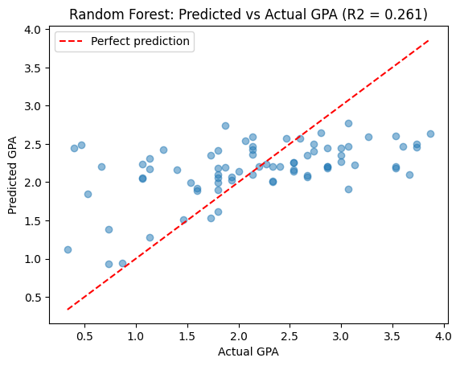

```python
plt.scatter(y_test_reg, y_rf_test_pred, alpha=0.5)
plt.plot([y_test_reg.min(), y_test_reg.max()],
         [y_test_reg.min(), y_test_reg.max()], 'r--', label='Perfect prediction')
plt.xlabel("Actual GPA")
plt.ylabel("Predicted GPA")
plt.title(f"Random Forest: Predicted vs Actual GPA (R2 = {r2_rf_test:.3f})")
plt.legend()
plt.show()
```

The large gap between train R2 = 0.747 and test R2 = 0.261 shows us that the model is overfitting, meaning it fails to generalize to the test set even with min_samples_leaf = 3 regularization being applied. This is captured in the plot which, much like with linear regression, shows significant variation between the predicted and actual GPA values.

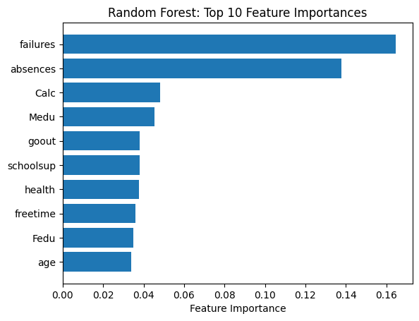

```python
importances = pd.Series(rf_model.feature_importances_, index=X_train.columns)
top_rf      = importances.sort_values(ascending=False).head(10)

plt.barh(top_rf.index[::-1], top_rf.values[::-1])
plt.xlabel("Feature Importance")
plt.title("Random Forest: Top 10 Feature Importances")
plt.show()
```

## Decision Tree

We train a decision tree limited to a depth of 3 on the PCA reduced features in order to avoid overfitting and compare to previous models. We also run 5 fold cross validation on the full training set to get a more reliable estimate of generalization performance.

```python
train_feature_pca = X_train_pca
test_feature_pca = X_test_pca
def trainDecisionTreeRegressor(train_feature_pca, train_labels, test_feature_pca, test_labels):

    model = DecisionTreeRegressor(max_depth = 3)
    model.fit(train_feature_pca, train_labels)

    trainRes = model.predict(train_feature_pca)
    testRes = model.predict(test_feature_pca)

    mse_train = mean_squared_error(train_labels, trainRes)
    mse_test = mean_squared_error(test_labels, testRes)
    r2_train = r2_score(train_labels, trainRes)
    r2_test = r2_score(test_labels, testRes)


    return model, mse_train, mse_test, r2_train, r2_test

train_labels = y_train_reg.values.ravel()
test_labels = y_test_reg.values.ravel()

model_dtr, mse_dt_train, mse_dt_test, r2_dt_train, r2_dt_test = trainDecisionTreeRegressor(
    train_feature_pca, train_labels,
    test_feature_pca, test_labels,
)

print("\nTrain Set MSE of Decision Tree Regressor: ", mse_dt_train)
print("\nTest Set MSE of Decision Tree Regressor: ", mse_dt_test)
print("\nTrain Set R2 Score of Decision Tree Regressor :", r2_dt_train)
print("\nTest Set of Decision Tree Regressor: ", r2_dt_test)
```

```
Train Set MSE of Decision Tree Regressor:  0.34398422428902165

Test Set MSE of Decision Tree Regressor:  0.7032650978929842

Train Set R2 Score of Decision Tree Regressor : 0.29179255381761326

Test Set of Decision Tree Regressor:  0.09456721996589112
```

```python
cvModel = DecisionTreeRegressor(random_state=42)

crossVal = KFold(n_splits=5, shuffle=True, random_state=42)

crossValScoreR2 = cross_val_score(cvModel, X_train_scaled, train_labels, cv = crossVal, scoring='r2')
crossValScoreMSE = cross_val_score(cvModel, X_train_scaled, train_labels, cv = crossVal, scoring='neg_mean_squared_error')

print("Cross-Validation R2 Scores:", crossValScoreR2)
print("Mean CV R2 score:", np.mean(crossValScoreR2))
print("Std CV R2 score:", np.std(crossValScoreR2))

print("\nCross-Validation MSE:", crossValScoreMSE)
print("Mean CV MSE:", np.mean(crossValScoreMSE))
print("Std CV MSE:", np.std(crossValScoreMSE))
```

```
Cross-Validation R2 Scores: [-1.09456388 -0.30806878 -1.10155891 -0.54330141 -0.34976239]
Mean CV R2 score: -0.6794510736472874
Std CV R2 score: 0.3508987996127454

Cross-Validation MSE: [-0.89156966 -0.68028219 -0.99505376 -0.72709677 -0.69849462]
Mean CV MSE: -0.7984994026284349
Std CV MSE: 0.1235882613535954
```

The test R2 of 0.095 is very weak, and the cross-validation results show a mean R2 of -0.68, suggesting that the model performs worse than simply predicting the mean GPA. This is likely because the single decision tree fails to capture the complexity that the random forest model is better suited for. As such, simplifying the model does not seem to improve predictive accuracy.

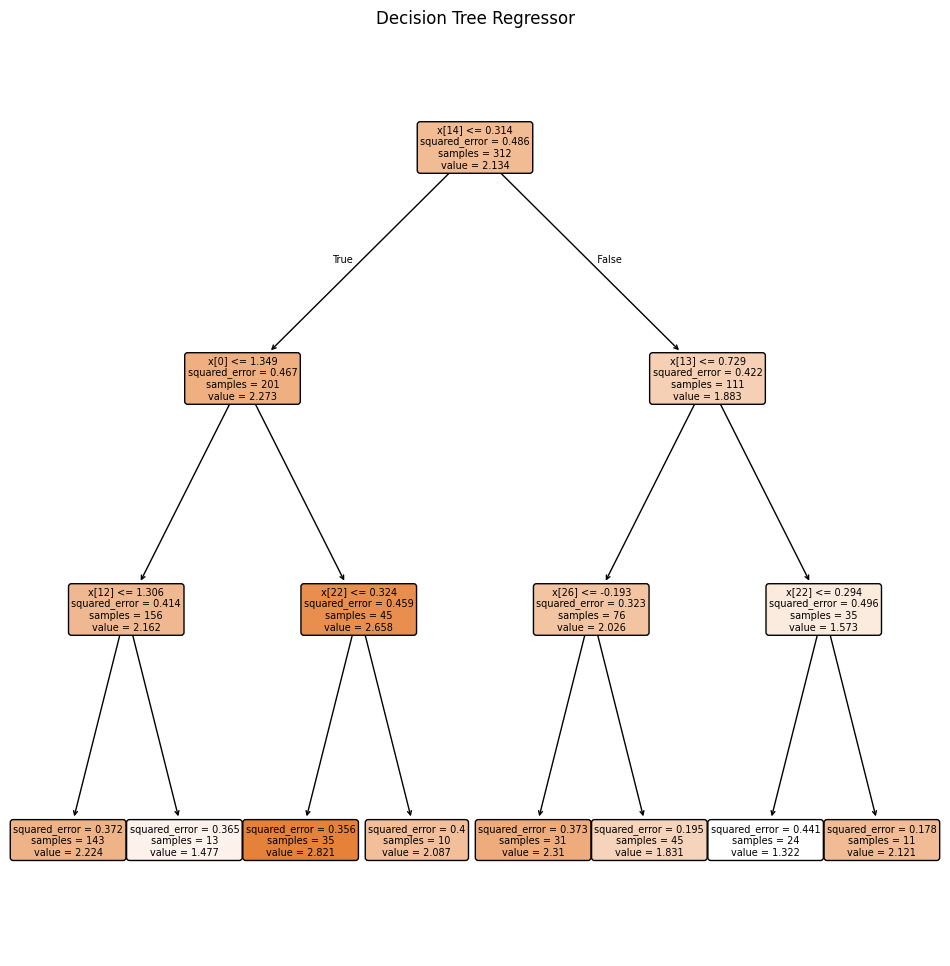

```python
plt.figure(figsize = (12, 12))
tree.plot_tree(model_dtr, filled = True, rounded = True)

plt.title("Decision Tree Regressor")
plt.show()
```

As depicted in the above plot, the high MSE at almost every node exemplifies how the decision tree is failing to capture the complexities of the data and make accurate predictions.

## Neural Network

We build a 3 layer Multi Layer Perceptron model on the PCA reduced features, scaling the GPA target before training. The model is trained for 100 epochs using Adam optimization and MSE loss, with the loss curve tracked to monitor training behavior over time. Because of the small size of our dataset, it is likely the neural network will overfit and provide poor accuracy. However, we are curious to see if it will have any success in capturing the evident complexities of the data set.

```python
y_scaler = StandardScaler()
y_train_scaled = y_scaler.fit_transform(y_train_reg.values.reshape(-1, 1))
y_test_scaled  = y_scaler.transform(y_test_reg.values.reshape(-1, 1))

X_train_tensor = torch.from_numpy(X_train_pca).to(torch.float32)
y_train_tensor = torch.from_numpy(y_train_scaled).to(torch.float32)
X_test_tensor  = torch.from_numpy(X_test_pca).to(torch.float32)
y_test_tensor  = torch.from_numpy(y_test_scaled).to(torch.float32)

train_dataset = TensorDataset(X_train_tensor, y_train_tensor)
test_dataset  = TensorDataset(X_test_tensor,  y_test_tensor)

batch_size = 32

generator = torch.Generator()
generator.manual_seed(42)

train_loader = DataLoader(train_dataset, batch_size=batch_size, shuffle=True, generator = generator)
test_loader  = DataLoader(test_dataset,  batch_size=batch_size, shuffle=False)

print(f"X_train_tensor shape: {X_train_tensor.shape}")
print(f"X_test_tensor shape:  {X_test_tensor.shape}")
print(f"y_train_tensor shape: {y_train_tensor.shape}")
print(f"y_test_tensor shape:  {y_test_tensor.shape}")
```

```
X_train_tensor shape: torch.Size([312, 28])
X_test_tensor shape:  torch.Size([78, 28])
y_train_tensor shape: torch.Size([312, 1])
y_test_tensor shape:  torch.Size([78, 1])
```

We create our neural network with a pyramid structure and use the ReLU activation function to add non-linearity and capture the complex relationships in the data.

```python
class MLPModel(nn.Module):
    def __init__(self, feat_dim):
        super(MLPModel, self).__init__()
        self.layer1 = nn.Linear(feat_dim, feat_dim * 2)
        self.layer2 = nn.Linear(feat_dim * 2, feat_dim)
        self.layer3 = nn.Linear(feat_dim, 1)

    def forward(self, x):
        ReLU = nn.ReLU()
        x = self.layer1(x)
        x = ReLU(x)
        x = self.layer2(x)
        x = ReLU(x)
        x = self.layer3(x)
        return x

model = MLPModel(feat_dim = train_loader.dataset[0][0].shape[0])
```

```python
criterion = nn.MSELoss()
optimizer = optim.Adam(model.parameters())

epochs = 100
losses = []
for epoch in range(epochs):
    running_loss = 0.0
    n_batches = 0
    for batch_idx, (data, targets) in enumerate(train_loader):
        optimizer.zero_grad()

        outputs = model(data)
        loss = criterion(outputs, targets)

        loss.backward()
        optimizer.step()

        running_loss += loss.item()
        n_batches += 1


    epoch_loss = running_loss / n_batches
    losses.append(epoch_loss)
    print(f'Epoch {epoch+1}/{epochs}, Loss: {epoch_loss}')

print('Finished Training')
```

[output not shown]

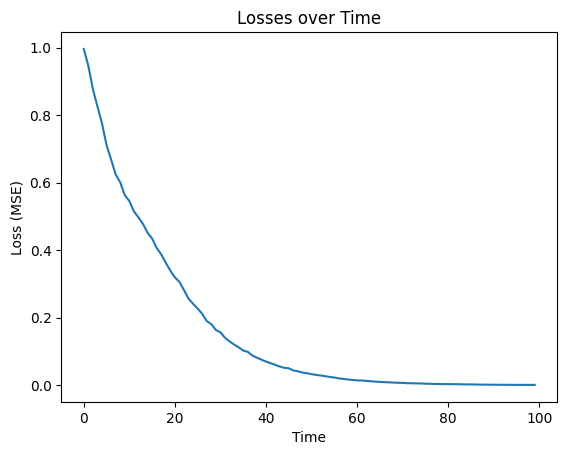

```
Train Set MSE of Neural Network:  0.0004734239460958634

Test Set MSE of Neural Network:  1.440194010734558

Train Set R2 Score of Neural Network:  0.9994536161422729

Test R2 Set of Neural Network:  -0.7300213575363159
```

```python
model.eval()

mse_nn_train = 0.0
mse_nn_test = 0.0
r2_nn_train = 0.0
r2_nn_test = 0.0

with torch.no_grad():
  for batch_idx, (data, targets) in enumerate(test_loader):
      loss = criterion(model(data), targets)
      r2 = r2_score(model(data).detach().numpy(), targets.detach().numpy())
      mse_nn_test += loss.item()
      r2_nn_test += r2
mse_nn_test = mse_nn_test / len(test_loader)
r2_nn_test = r2_nn_test / len(test_loader)

with torch.no_grad():
  for batch_idx, (data, targets) in enumerate(train_loader):
      loss = criterion(model(data), targets)
      r2 = r2_score(model(data).detach().numpy(), targets.detach().numpy())
      mse_nn_train += loss.item()
      r2_nn_train += r2

mse_nn_train = mse_nn_train / len(train_loader)
r2_nn_train = r2_nn_train /  len(train_loader)

plt.plot(losses)
plt.title("Losses over Time")
plt.xlabel("Time")
plt.ylabel("Loss (MSE)")
plt.show()

print("\nTrain Set MSE of Neural Network: ", mse_nn_train)
print("\nTest Set MSE of Neural Network: ", mse_nn_test)
print("\nTrain Set R2 Score of Neural Network: ", r2_nn_train)
print("\nTest R2 Set of Neural Network: ", r2_nn_test)
```

The test R2 of -0.73 is very poor, while the train R2 of 0.99 suggests that the neural network is overfitting on the training data. As predicted, the dataset is likely to small for training a neural network. If we were able to obtain a larger dataset the neural network would perhaps be valuable for capturing the complex, non-linear relationships in the data, but for now it is not useful for predicting GPA.

## Model Comparison

We will now plot and compare the performances of the four models we analysed for predicting GPA.

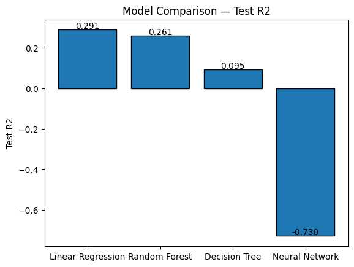

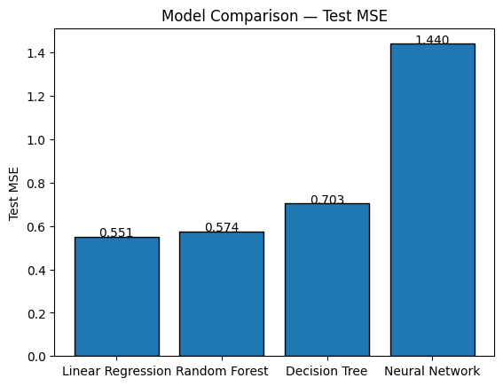

```python
model_names = ['Linear Regression', 'Random Forest', 'Decision Tree', 'Neural Network']
test_r2s    = [r2_lr_test, r2_rf_test, r2_dt_test, r2_nn_test]
test_mses   = [mse_lr_test, mse_rf_test, mse_dt_test, mse_nn_test]

plt.bar(model_names, test_r2s, edgecolor='black')
plt.ylabel("Test R2")
plt.title("Model Comparison — Test R2")
for i, v in enumerate(test_r2s):
    plt.text(i, v + 0.005, f'{v:.3f}', ha='center')
plt.show()

plt.bar(model_names, test_mses, edgecolor='black')
plt.ylabel("Test MSE")
plt.title("Model Comparison — Test MSE")
for i, v in enumerate(test_mses):
    plt.text(i, v + 0.001, f'{v:.3f}', ha='center')
plt.show()
```

# Insights and Conclusions

While we were able to conclude that many lifestyle factors have a significant impact on GPA, we were not able to succesfully create a predictive model for our GPA. All of the models we trained suffered from different problems. Linear regression had the best test R2 score of 0.291, meaning it was able to explain a small part of the variation in GPA, but clearly failed to capture the complex non-linear relationships between features. Random forest had a slightly lower test R2 score of 0.261, with a higher train R2 score of 0.747, suggesting it was able to adress some of the complexities of the data but was also overfitting on the dataset. The decision tree had a very low test R2 score of 0.095, suggesting that its simplicity and limited depth entirely failed to capture the complexity of the data. Lastly, our neural network have a very poor test R2 score of -0.73, compared to a train R2 score of 0.99, suggesting that it was strongly overfitting on the small data set. The inability of all of our models to accurately predict the GPAs of students could be because of several different factors. For one, it is possible that there is a lot of randomness when it comes to how lifestyle factors relate to GPA, and that no factor is strongly enough tied to academic performance that it can be used to accurately predict GPA. Additionally, it is possible that this data set was simply to small for training a model that is actually able to capture all the complexities of the data, such as a neural network. To address this, decision makers could collect more data on students so that they can create a better predictive model that will enable them to predict which students are at risk and provide them with support.

Overall, this project suggests that predicting academic performance, at least with the provided data set, is challenging. However, we were still able to find some lifestyle factors that did correlate to academic performance, and we also found that alcohol consumption does indeed impact GPA. We also were able to experience some of the shortcomings of machine learning, and we learned the importance of having access to good data in order to produce good results.

# Citations

CDC. “About Underage Drinking.” Alcohol Use, 14 Jan. 2025, www.cdc.gov/alcohol/underage-drinking/index.html./  
Cortez, Paulo and Alice Silva. "Student Performance." UCI Machine Learning Repository, 2008, https://doi.org/10.24432/C5TG7T.  
Alam, Fardina. "Homework 5." University of Maryland, College Park, 2026, https://umd.instructure.com/courses/1398412/assignments/7539590  
Alam, Fardina. "Homework 4." University of Maryland, College Park, 2026, https://umd.instructure.com/courses/1398412/assignments/7539589  
Alam, Fardina. "Homework 3." University of Maryland, College Park, 2026, https://umd.instructure.com/courses/1398412/assignments/7539588  
Alam, Fardina. "Homework 2." University of Maryland, College Park, 2026, https://umd.instructure.com/courses/1398412/assignments/7539587  
Alam, Fardina. "Homework 1." University of Maryland, College Park, 2026, https://umd.instructure.com/courses/1398412/assignments/7539586